# Calender Query - An analysis of how I spent my study time

# Introduction

Federal Higher Education accreditation guidelines require at least 12 hours per week for each course, including class and lab times. I have always wondered if this is the case for the courses I take. I think that at times I spend more time on some courses than others, depending on how much I enjoy them, how difficult I find them or how much work I am assigned for the course. I decided to track my time allocation for my courses over a period of two weeks to see what patterns showed up in the way I study. My initial question was:

- What course do I spend most of my time on and does it meet the recommended time?

I also became interested in finding out if my workflow changed depending on whether it was a weekday or a weekend, and if certain days were more busy for me than others. This information would help me to distribute my efforts more evenly and possibly restructure my schedule to put more effort to other courses. I was also interested in looking back at the results to see if they were indicative of the grades I would get at the end of the semester.

# Methods

## Data collection

I use my *iCloud* calender to keep track of my schedule and weekly commitments, since it is synced across my phone, Mac and iPad. The calender contains other commitments not related to this particular study so I used *Toggl* to keep track of my time commitments for each course I was taking. Every time my calender indicated that I was beginning work for a course, I would create an event on *Toggl* named after the course I was working on. In this way, I had a calender dedicated solely for my courses that I exported as a csv at the end of the two week period. Having two calenders also helped me to verify my entries for this project. If I forgot to add an event to my *Toggl* tracker, I could always refer to my *iCloud* calender to see how I had spent my day with regards to my courses.

## Data wrangling

I used the `tidyverse` suite of packages, `lubridate`, and `glue` to wrangle and prepare the data. I separated the data by weeks so that I could see the trends separately per week. I also separated the days into weekdays and weekends so that I could see how the time distribution varied over the two day types. Sometimes I would work on the same course twice a day separately, so I had to sum for each course per day. I also summed the hours spent per course over the 14 days as well as per week. I did the same with the average time as well as the standard deviation.

```r
# Data import: toggl
toggl_main <- read_csv("data/michael-data.csv")

# Data wrangling
coursetime<- toggl_main %>%
  rename(course = Description)%>%
  clean_names() %>%
  mutate(
    # Create date-times from separate dates and times for calculating duration
    start = ymd_hms(glue("{start_date} {start_time}"),
                    tz = "America/New_York"),
    end = ymd_hms(glue("{end_date} {end_time}"),
                  tz = "America/New_York"),

       duration_hours = interval(start, end) / hours(1),

    across(c(course, tags),
           .fns = str_squish))

#get weekdays from the `start_date`
coursetime$weekday <- weekdays(coursetime$start_date)

#create a new data frame that is cleaner to separate weeks and weekday and weekends
coursetime2 <- coursetime %>%
  group_by(start_date, course) %>%
  #add all hours for the same course per day
  summarise(duration_hours = sum(duration_hours)) %>%
  #make each course a variable
  pivot_wider(names_from = "course",
              values_from = "duration_hours")
```

```r
#Compute total and average duration for each course over the 14 days
course_summary <- coursetime %>%
  group_by(course) %>%
  summarise( course_total = sum(duration_hours),
             course_average = round(course_total/14, digits = 2),
             course_sd = round(sd(duration_hours), digits = 2)) %>%
  #combine `course_average` and `course_sd` into one column
  mutate(course_average = glue('{course_average} ({course_sd})')) %>%
  arrange(desc(course_total))


#remove the column for `course_sd`
course_summary <- subset(course_summary, select = -c(course_sd))
```

```r
#Create variables to show weeks (week 1 and week 2) as well as day type
#(weekday vs weekend)
course_weekly <- coursetime2 %>%
  select(start_date, English,
         `Data Science`,
         `Machine Learning`,
         Algorithms) %>%
  #change courses from separate columns into one
  pivot_longer(cols = -start_date,
               names_to = "course",
               values_to = "duration-hours") %>%
  #make each date a column
  pivot_wider(names_from = "start_date",
              values_from = "duration-hours") %>%
  #rename date columns into week1 and week2 variables
  rename("Week1.Saturday" = "2022-09-10",
         "Week1.Sunday" = "2022-09-11",
         "Week1.Monday" = "2022-09-12",
         "Week1.Tuesday" = "2022-09-13",
         "Week1.Wednesday" = "2022-09-14",
         "Week1.Thursday" = "2022-09-15",
         "Week1.Friday" = "2022-09-16",
         "Week2.Saturday" = "2022-09-17",
         "Week2.Sunday" = "2022-09-18",
         "Week2.Monday" = "2022-09-19",
         "Week2.Tuesday" = "2022-09-20",
         "Week2.Wednesday" = "2022-09-21",
         "Week2.Thursday" = "2022-09-22",
         "Week2.Friday" = "2022-09-23") %>%
  #assign renamed dates to `weekday` variable in one column
  pivot_longer(cols = -course,
               names_to = "weekday",
               values_to = "duration_hours") %>%
  #create new variables -- `week` and `weekday` separated by '.'
  separate(col = weekday, into = c("week", "weekday"), sep="\\.") %>%
  #make `weekday` a categorical variable and assign values
  mutate(weekday = factor(weekday, levels = c("Monday",
                                              "Tuesday",
                                              "Wednesday",
                                              "Thursday",
                                              "Friday",
                                              "Saturday",
                                              "Sunday")),
         #separate weekdays and weekend days
         weekday_type = fct_collapse(weekday,
                                weekday = c("Monday",
                                              "Tuesday",
                                              "Wednesday",
                                              "Thursday",
                                              "Friday"),
                                weekend = c( "Saturday",
                                              "Sunday")))
```

```r
# Compute the total and average time per course for each week
weekly_summary <- course_weekly %>%
pivot_wider(names_from = "week",
            values_from = "duration_hours") %>%
  group_by(course) %>%
  summarise(week1_total = sum(Week1),
            week1_avg = round(week1_total/7, digits = 2),
            week1_sd = round(sd(Week1), digits = 2),
            week2_total = sum(Week2),
            week2_avg = round(week2_total/7, digits = 2),
            week2_sd = round(sd(Week2), digits = 2)) %>%
  #put the mean and standard deviation on one column
  mutate(week1_avg = glue('{week1_avg} ({week1_sd})'),
         week2_avg = glue('{week2_avg} ({week2_sd})'))%>%
  arrange(desc(week1_total))

#remove the columns for `week1_sd` and `week2_sd`
weekly_summary <- subset(weekly_summary, select = -c(week1_sd,
                                                     week2_sd))
```

```r
#Compute the total time per day for each course over the 14 days
fortnight_distribution <- coursetime %>%
  group_by(start_date,
          course) %>%
  #sum course hours per day
 summarise(course_time = sum(duration_hours))
```

## Statistical methods

I computed descriptive statistics (total, mean and standard deviation) to determine two things. The first set was to determine which courses I spent the most and least time on over the two week period. The second set was to determine how the time allocation changed for each course over the two week period and whether it met the minimum recommended time.

The `ggplot` and `scales` packages were used to create each visualization and `kableExtra` was used to customize each table.

# Results

Firstly, I wanted to see how my time allocation per course varied over the 14 days over which I collected this data.Figure 1 shows the time distribution from September 10 to September 23 for each course. From the plot, we can see that on average, I spend more time on Data Science than any other course. I also tend to spend little time on Machine learning save for the huge spike on September 18, which corresponds to the time when I was setting up for a project in the class. I do not spend as much time on Algorithms, especially in the second week.

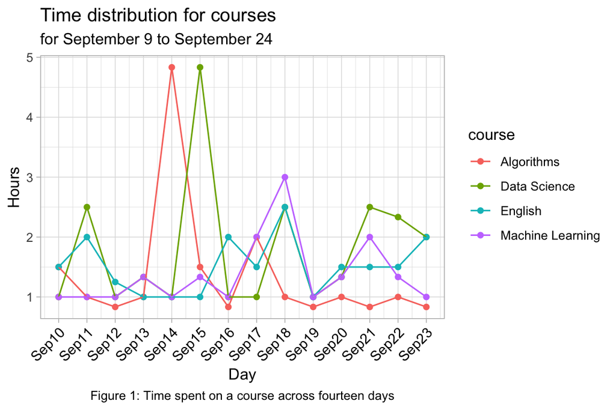

```r
g <- ggplot(fortnight_distribution,
            mapping = aes(x = start_date,
                          y = course_time,
                          color = course)) +
  geom_point() +
  geom_line() +
  labs(title = "Time distribution for courses",
       subtitle = "for September 9 to September 24",
       caption = "Figure 1: Time spent on a course across fourteen days",
       x = "Day",
       y = "Hours") +
  #set the scale for the axis and display the dates as month and date
  scale_x_date(breaks = "1 day",
               date_labels = "%b%d") +
    theme_light() +
  #set the position and specifics of the caption and x axis titles
theme(axis.text.x = element_text(size = 10,
                                 angle = 45,
                                 color = "black",
                                 vjust = 1,
                                 hjust = 1),
      plot.caption = element_text(hjust = 0.5))

g
```

I was also interested in seeing the differences in my time commitments to my courses between weekdays and weekends. Figure 3 helps me to answer this question as it separates my time distribution over the two weeks by weekday type. From the plot, it is clear that I tend to have busier Sundays than Saturdays, which is evidence of my preparation for the week ahead. An exception to this is Algorithms,for which I tend to do more work for on Saturdays than Sundays.

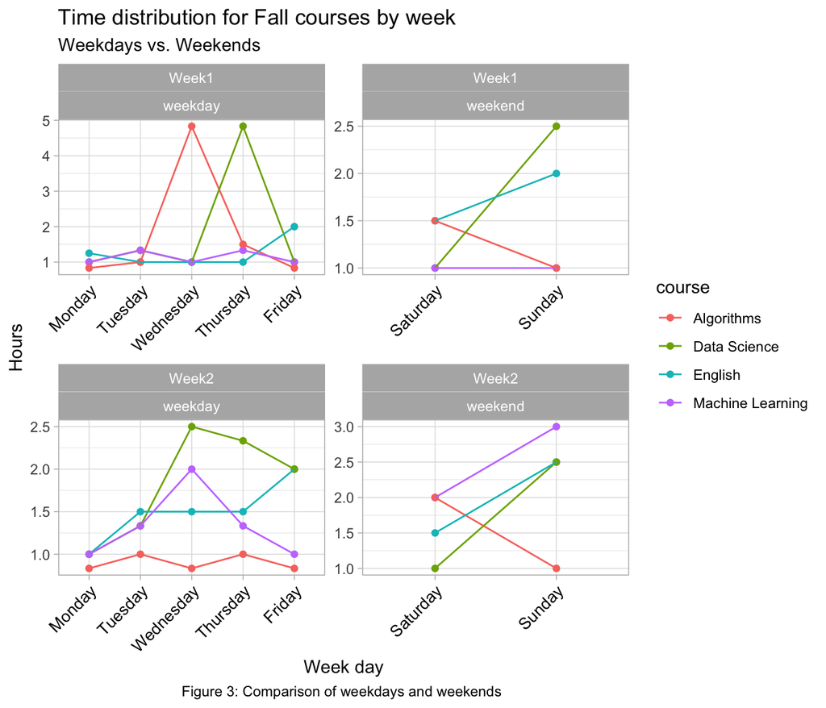

```r
g <- ggplot(course_weekly, mapping = aes(x = weekday,
                                       y = duration_hours,
                                       color = course,
                                       group = course)) +
  geom_point() +
  geom_line() +
  labs(title = "Time distribution for Fall courses by week",
       subtitle = "Weekdays vs. Weekends",
       caption = "Figure 3: Comparison of weekdays and weekends ",
       x = "Week day",
       y = "Hours") +
  theme_light() +
    #set the position and specifics of the caption and x axis titles
  theme(axis.text.x = element_text(size = 10,
                                 angle = 45,
                                 color = "black",
                                 vjust = 1,
                                 hjust = 1),
        plot.caption = element_text(hjust = 0.5)) +
  #seperate the plots by week and weekday type
  facet_wrap(week~weekday_type, scales = 'free')

g
```

The plots are helpful for seeing trends in my data, however they do not give me values that would help me determine which courses I spend the most and least time on.Table 1 helps me to determine this. The table shows that I tend to spend more time on Data Science followed by English, Machine Learning and lastly Algorithms. This table slightly aligns with my course interests as well as the workload I have for each course.

```r
course_summary %>%
  kable(col.names = c("Course",
                      "Total",
                      "Average(SD)"),
        booktabs = TRUE,
        digits = 2,
        align = "lcc",
        caption = "Course Summary over the 14 days") %>%
  kable_styling(latex_options = "HOLD_position") %>%
  add_header_above(header = c(" " = 1,
                              "Time spent in hours" = 2),
                   bold = TRUE) %>%
  row_spec(row = c(0), bold = TRUE)
```

Course Summary over the 14 days

| Course | Time spent in hours Total | Time spent in hours Average(SD) |
| --- | --- | --- |
| Data Science | 25.33 | 1.81 (0.77) |
| English | 21.25 | 1.52 (0.46) |
| Machine Learning | 19.33 | 1.38 (0.58) |
| Algorithms | 19.00 | 1.36 (0.83) |

Table 2 further helps me to determine whether I am spending the recommended time per course per week. From the table, we can see that for the first and second week, I spent the recommended time for Data Science. I almost spent the recommended time on Algorithms for the first week but this dropped down for the second week. In contrast, I did not meet the minimum required time for English and Machine Learning during the first week but improved on the second week.

```r
 weekly_summary %>%
  kable(col.names = c("Course",
                      "Total",
                      "Mean(SD)",
                       "Total",
                       "Mean(SD)"
                      ),
        booktabs = TRUE,
        digits = 2,
        align = "lcc",
        caption = "Course Summary by Week") %>%
  kable_styling(latex_options = "HOLD_position") %>%
  add_header_above(header = c(" " = 1,
                   "Week 1" = 2, "Week 2" = 2),
                   bold = TRUE) %>%
  add_header_above(header = c(" " = 1,
                              "Time spent in hours" = 4),
                   bold = TRUE) %>%
  row_spec(row = c(0), bold = TRUE)
```

Course Summary by Week

| Course | Time spent in hours Week 1 Total | Time spent in hours Week 1 Mean(SD) | Time spent in hours Week 2 Total | Time spent in hours Week 2 Mean(SD) |
| --- | --- | --- | --- | --- |
| Data Science | 12.67 | 1.81 (1.44) | 12.67 | 1.81 (0.68) |
| Algorithms | 11.50 | 1.64 (1.44) | 7.50 | 1.07 (0.42) |
| English | 9.75 | 1.39 (0.45) | 11.50 | 1.64 (0.48) |
| Machine Learning | 7.67 | 1.1 (0.16) | 11.67 | 1.67 (0.72) |

# Conclusions

It was interesting to learn that my time commitment to my studies has improved over the two weeks of the study. I have always thought that I start my semester on a high note and falter as the semester progresses which does not appear to be the case here. It was also interesting to learn that I am putting more work towards Data Science and English as opposed to Machine Learning and Algorithms. This is quite surprising considering that I am the only student in the Special Topics English class I am taking and meet only once a week with the professor.

I did not know that my time commitments peaked around Wednesday and Sunday. This could really inform how I set up my week and redistribute my effort so that I do not overwhelm myself on the two days. I was slightly concerned that I am using the recommended time for Data Science only. I am also concerned because I am wondering if this project helped me to put more time to the course, and whether that will remain the case once I finish it.

Moving forward, I hope to be more consistent with my time allocation per course and to use the recommended time for each course. I am considering setting aside more time for my courses, particularly Algorithms.

# Reflection

I would need to collect data for a month in order to satisfactorily answer my questions because this is enough time to downplay the effects of fluctuations in course time due to projects or midterms which may distort the accuracy of how I spent my time.

The main difficulties in data collection were consistency. I don’t usually actively track the time I spend on courses so I had to remind myself a few times to record when I was working on my studies. Having two calenders helped a little with keeping track of my time since I could fill in missing gaps in my *Toggl* track calender by referencing my *iCloud* Calender.

One lesson that I learnt from this project is that wrangling takes just as much time as data collection. One thing that really helped me to be more efficient with my analysis was that I started wrangling as soon as I had collected a small amount of data. This helped me set up my wrangling procedure which I just had to scale up as needed once I had collected all my data. This is a really efficient method that I hope to use for future projects.

## R Packages

Allaire, JJ, Yihui Xie, Jonathan McPherson, Javier Luraschi, Kevin Ushey, Aron Atkins, Hadley Wickham, Joe Cheng, Winston Chang, and Richard Iannone. 2022. *Rmarkdown: Dynamic Documents for r*. https://CRAN.R-project.org/package=rmarkdown.

Firke, Sam. 2021. *Janitor: Simple Tools for Examining and Cleaning Dirty Data*. https://github.com/sfirke/janitor.

Grolemund, Garrett, and Hadley Wickham. 2011. “Dates and Times Made Easy with lubridate.” *Journal of Statistical Software* 40 (3): 1–25. https://www.jstatsoft.org/v40/i03/.

Henry, Lionel, and Hadley Wickham. 2020. *Purrr: Functional Programming Tools*. https://CRAN.R-project.org/package=purrr.

Hester, Jim, and Jennifer Bryan. 2022. *Glue: Interpreted String Literals*. https://CRAN.R-project.org/package=glue.

Meissner, Peter. 2019. *Ical: iCalendar Parsing*. https://CRAN.R-project.org/package=ical.

Müller, Kirill, and Hadley Wickham. 2022. *Tibble: Simple Data Frames*. https://CRAN.R-project.org/package=tibble.

R Core Team. 2022. *R: A Language and Environment for Statistical Computing*. Vienna, Austria: R Foundation for Statistical Computing. https://www.R-project.org/.

Spinu, Vitalie, Garrett Grolemund, and Hadley Wickham. 2021. *Lubridate: Make Dealing with Dates a Little Easier*. https://CRAN.R-project.org/package=lubridate.

Wickham, Hadley. 2016. *Ggplot2: Elegant Graphics for Data Analysis*. Springer-Verlag New York. https://ggplot2.tidyverse.org.

———. 2022a. *Forcats: Tools for Working with Categorical Variables (Factors)*. https://CRAN.R-project.org/package=forcats.

———. 2022b. *Stringr: Simple, Consistent Wrappers for Common String Operations*. https://CRAN.R-project.org/package=stringr.

———. 2022c. *Tidyverse: Easily Install and Load the Tidyverse*. https://CRAN.R-project.org/package=tidyverse.

Wickham, Hadley, Mara Averick, Jennifer Bryan, Winston Chang, Lucy D’Agostino McGowan, Romain François, Garrett Grolemund, et al. 2019. “Welcome to the tidyverse.” *Journal of Open Source Software* 4 (43): 1686. https://doi.org/10.21105/joss.01686.

Wickham, Hadley, Winston Chang, Lionel Henry, Thomas Lin Pedersen, Kohske Takahashi, Claus Wilke, Kara Woo, Hiroaki Yutani, and Dewey Dunnington. 2022. *Ggplot2: Create Elegant Data Visualisations Using the Grammar of Graphics*. https://CRAN.R-project.org/package=ggplot2.

Wickham, Hadley, Romain François, Lionel Henry, and Kirill Müller. 2022. *Dplyr: A Grammar of Data Manipulation*. https://CRAN.R-project.org/package=dplyr.

Wickham, Hadley, and Maximilian Girlich. 2022. *Tidyr: Tidy Messy Data*. https://CRAN.R-project.org/package=tidyr.

Wickham, Hadley, Jim Hester, and Jennifer Bryan. 2022. *Readr: Read Rectangular Text Data*. https://CRAN.R-project.org/package=readr.

Xie, Yihui. 2014. “Knitr: A Comprehensive Tool for Reproducible Research in R.” In *Implementing Reproducible Computational Research*, edited by Victoria Stodden, Friedrich Leisch, and Roger D. Peng. Chapman; Hall/CRC. http://www.crcpress.com/product/isbn/9781466561595.

———. 2015. *Dynamic Documents with R and Knitr*. 2nd ed. Boca Raton, Florida: Chapman; Hall/CRC. https://yihui.org/knitr/.

———. 2022. *Knitr: A General-Purpose Package for Dynamic Report Generation in r*. https://yihui.org/knitr/.

Xie, Yihui, J. J. Allaire, and Garrett Grolemund. 2018. *R Markdown: The Definitive Guide*. Boca Raton, Florida: Chapman; Hall/CRC. https://bookdown.org/yihui/rmarkdown.

Xie, Yihui, Christophe Dervieux, and Emily Riederer. 2020. *R Markdown Cookbook*. Boca Raton, Florida: Chapman; Hall/CRC. https://bookdown.org/yihui/rmarkdown-cookbook.

Zhu, Hao. 2021. *kableExtra: Construct Complex Table with Kable and Pipe Syntax*. https://CRAN.R-project.org/package=kableExtra.